# Python Foundations Project: Austo

## Problem Statement

### Context

In the 21st century, cars are an important mode of transportation that provides us the opportunity for personal control and autonomy. In day-to-day life, people use cars for commuting to work, shopping, visiting family and friends, etc. Research shows that more than 76% of people prevent themselves from traveling somewhere if they don't have a car. Most people tend to buy different types of cars based on their day-to-day necessities and preferences. So, it is essential for automobile companies to analyze the preference of their customers before launching a car model into the market. Austo, a UK-based automobile company aspires to grow its business into the US market after successfully establishing its footprints in the European market.

In order to be familiar with the types of cars preferred by the customers and factors influencing the car purchase behavior in the US market, Austo has contracted a consulting firm. Based on various market surveys, the consulting firm has created a dataset of 3 major types of cars that are extensively used across the US market. They have collected various details of the car owners which can be analyzed to understand the automobile market of the US.

### Objective

Austo's management team wants to understand the demand of the buyers and trends in the US market. They want to build customer profiles based on the analysis to identify new purchase opportunities so that they can manipulate the business strategy and production to meet certain demand levels. Further, the analysis will be a good way for management to understand the dynamics of a new market. Suppose you are a Data Scientist working at the consulting firm that has been contracted by Austo. You are given the task to create buyer's profiles for different types of cars with the available data as well as a set of recommendations for Austo. Perform the data analysis to generate useful insights that will help the automobile company to grow its business.

### Data Description

austo_automobile.csv: The dataset contains buyer's data corresponding to different types of products(cars).

### Data Dictionary

- Age: Age of the customer
- Gender: Gender of the customer
- Profession: Indicates whether the customer is a salaried or business person
- Marital_status: Marital status of the customer
- Education: Refers to the highest level of education completed by the customer
- No_of_dependents: Number of dependents(partner/children/spouse) of the customer
- Personal_loan: Indicates whether the customer availed a personal loan or not
- House_loan: Indicates whether the customer availed house loan or not
- Partner_working: Indicates whether the customer's partner is working or not
- Salary: Annual Salary of the customer
- Partner_salary: Annual Salary of the customer's partner
- Total_salary: Annual household income (Salary + Partner_salary) of the customer's family
- Price: Price of the car
- Make: Car type (Hatchback/Sedan/SUV)

## Importing necessary libraries

```python
# Installing the libraries with the specified version.
!pip install numpy==1.25.2 pandas==1.5.3 matplotlib==3.7.1 seaborn==0.13.1 -q --user
```

[output not shown]

**Note**: *After running the above cell, kindly restart the notebook kernel and run all cells sequentially from the start again.*

```python
# import libraries for data manipulation
import numpy as np
import pandas as pd

# import libraries for data visualization
import matplotlib.pyplot as plt
import seaborn as sns
import warnings
warnings.filterwarnings('ignore')
```

```python
path = '//Users//Larriet//Documents//Education//Python//python project//austo_automobile.csv'
```

## Importing the dataset

```python
# uncomment and run the following lines for Google Colab
# from google.colab import drive
# drive.mount('/content/drive')
```

```python
# read the data
df=pd.read_csv(path)
# returns the first 5 rows
df.head()
```

|  | Age | Gender | Profession | Marital_status | Education | No_of_Dependents | Personal_loan | House_loan | Partner_working | Salary | Partner_salary | Total_salary | Price | Make |
| --- | --- | --- | --- | --- | --- | --- | --- | --- | --- | --- | --- | --- | --- | --- |
| 0 | 24 | Male | Salaried | Married | Post Graduate | 4 | No | Yes | Yes | 52000 | 25000 | 77000 | 18000 | Hatchback |
| 1 | 28 | Male | Salaried | Married | Post Graduate | 3 | No | Yes | No | 68000 | 0 | 68000 | 18000 | Hatchback |
| 2 | 23 | Male | Salaried | Married | Graduate | 4 | Yes | Yes | No | 31000 | 0 | 31000 | 18000 | Hatchback |
| 3 | 26 | Male | Business | Married | Post Graduate | 4 | Yes | Yes | Yes | 66000 | 35000 | 101000 | 18000 | Hatchback |
| 4 | 28 | Male | Business | Married | Post Graduate | 4 | Yes | No | No | 64000 | 0 | 64000 | 18000 | Hatchback |

## Data Overview

#### Question 1: How many rows and columns are present in the data? [0.5 mark]

```python
df.shape
```

```
(1581, 14)
```

#### Observations: This set has 1581 rows and 14 columns

#### Question 2: What are the datatypes of the different columns in the dataset? [0.5 mark]

```python
df.info()
```

```
<class 'pandas.core.frame.DataFrame'>
RangeIndex: 1581 entries, 0 to 1580
Data columns (total 14 columns):
 #   Column            Non-Null Count  Dtype
---  ------            --------------  -----
 0   Age               1581 non-null   int64
 1   Gender            1581 non-null   object
 2   Profession        1581 non-null   object
 3   Marital_status    1581 non-null   object
 4   Education         1581 non-null   object
 5   No_of_Dependents  1581 non-null   int64
 6   Personal_loan     1581 non-null   object
 7   House_loan        1581 non-null   object
 8   Partner_working   1581 non-null   object
 9   Salary            1581 non-null   int64
 10  Partner_salary    1581 non-null   int64
 11  Total_salary      1581 non-null   int64
 12  Price             1581 non-null   int64
 13  Make              1581 non-null   object
dtypes: int64(6), object(8)
memory usage: 173.1+ KB
```

#### Observations: The data set includes 6 numerical integar columes and 8 columns containing objects. The intgers include age, no. of dependents, salary, total salary, partner salary, and price. The object includes education, personal loan, house loan, gender, profession, martial status, make, and partner working.

#### Question 3: Check the statistical summary of the data. What is the minimu, avergae, and maximum Price of the cars? [2 marks]

```python
df.describe().T
```

|  | count | mean | std | min | 25% | 50% | 75% | max |
| --- | --- | --- | --- | --- | --- | --- | --- | --- |
| Age | 1581.0 | 32.211259 | 9.125477 | 22.0 | 25.0 | 29.0 | 38.0 | 60.0 |
| No_of_Dependents | 1581.0 | 2.457938 | 0.943483 | 0.0 | 2.0 | 2.0 | 3.0 | 4.0 |
| Salary | 1581.0 | 59732.447818 | 14278.642665 | 30000.0 | 51000.0 | 59000.0 | 71000.0 | 90000.0 |
| Partner_salary | 1581.0 | 19720.430108 | 19480.214404 | 0.0 | 0.0 | 25000.0 | 38000.0 | 80000.0 |
| Total_salary | 1581.0 | 79452.877925 | 24855.936043 | 30000.0 | 61000.0 | 78000.0 | 96000.0 | 158000.0 |
| Price | 1581.0 | 35597.722960 | 13633.636545 | 18000.0 | 25000.0 | 31000.0 | 47000.0 | 70000.0 |

#### Question 4: Are there any missing values in the data? If yes, treat them using an appropriate method. [1 Mark]

```python
df.isnull().sum()
```

```
Age                 0
Gender              0
Profession          0
Marital_status      0
Education           0
No_of_Dependents    0
Personal_loan       0
House_loan          0
Partner_working     0
Salary              0
Partner_salary      0
Total_salary        0
Price               0
Make                0
dtype: int64
```

#### Observations: There are zero missing values

#### Question 5: How many cars are there of type SUV? [1 mark]

```python
type_cols=['Make']
for column in type_cols:
    print(df[column].value_counts())
print("_"*50)
```

```
Make
Hatchback    884
Sedan        460
SUV          237
Name: count, dtype: int64
__________________________________________________
```

#### Observations:

As we can see, there are 237 in SUV

## Exploratory Data Analysis (EDA)

### Univariate Analysis

#### **Question 6:** Explore all the variables and provide observations on their distributions. (Generally, histograms, boxplots, countplots, etc. are used for univariate exploration.) [10 marks]

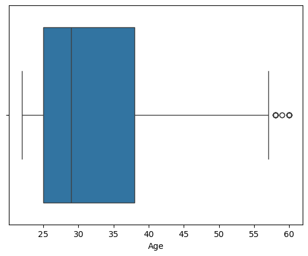

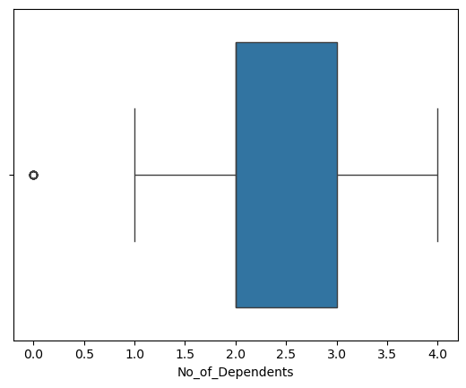

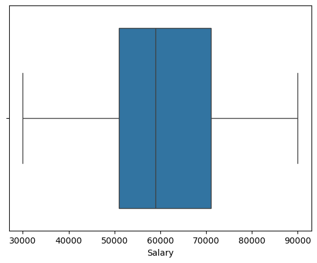

```python
sns.boxplot(data=df,x='Age')
plt.show()
sns.boxplot(data=df,x='No_of_Dependents')
plt.show()
sns.boxplot(data=df,x='Salary')
plt.show()
```

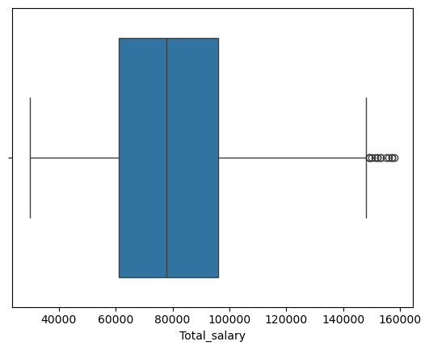

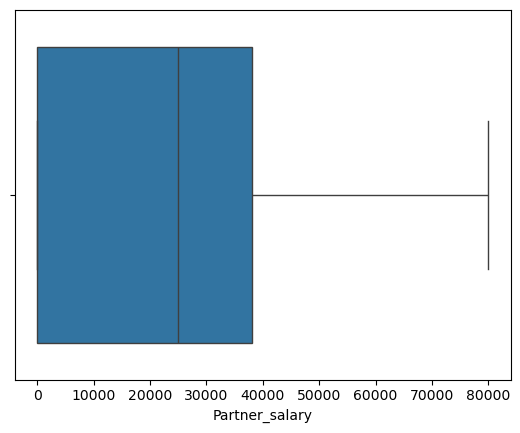

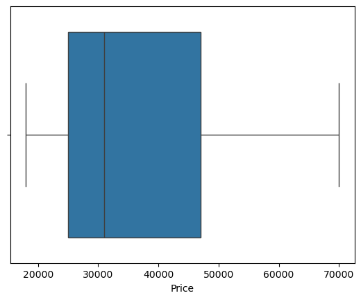

```python
sns.boxplot(data=df,x='Total_salary')
plt.show()
sns.boxplot(data=df,x='Partner_salary')
plt.show()
sns.boxplot(data=df,x='Price')
plt.show()
```

#### Observations: In the boxplot, the age and and distribution variables are skewed to the right. The total salaries seem to be normally distributed outside from outliers. There is an outliers for no of dependents. Price has no outliers and is more to the right.

#### Question 7: How many cars are of make Hatchback and priced above 25000. State your observations? [2 marks]

```python
hatchback_above25=df.loc[(df['Price']>25000)&(df['Make']=='Hatchback')]
hatchback_above25.count()
```

```
Age                 444
Gender              444
Profession          444
Marital_status      444
Education           444
No_of_Dependents    444
Personal_loan       444
House_loan          444
Partner_working     444
Salary              444
Partner_salary      444
Total_salary        444
Price               444
Make                444
dtype: int64
```

#### Observations:444 hatchbacks are prices above 25000

#### Question 8: How many owners have bought cars that were priced higher than their salary. How many of them have taken personal loan? [3 marks]

```python
price_higher_salary=df.loc[df['Price'] - df['Salary'] > 0]
price_higher_salary.count()
```

```
Age                 96
Gender              96
Profession          96
Marital_status      96
Education           96
No_of_Dependents    96
Personal_loan       96
House_loan          96
Partner_working     96
Salary              96
Partner_salary      96
Total_salary        96
Price               96
Make                96
dtype: int64
```

```python
price_higher_with_personal_loan=df.loc[(df['Price'] - df['Salary'] > 0)&(df['Personal_loan']=='Yes')]
price_higher_with_personal_loan.count()
```

```
Age                 44
Gender              44
Profession          44
Marital_status      44
Education           44
No_of_Dependents    44
Personal_loan       44
House_loan          44
Partner_working     44
Salary              44
Partner_salary      44
Total_salary        44
Price               44
Make                44
dtype: int64
```